# Basics of graphs

- Load the tidyverse

Let’s consider the following table (non real data)

```r
hours <- c(0.5, 1, 1.5, 2, 2.5, 3)

improvement <- c( 12, 25, 40, 83, 120, 125)

table_scz <- data.frame(hours, improvement)
```

```r
table_scz
```

| hours | improvement |
| --- | --- |
| 0.5 | 12 |
| 1.0 | 25 |
| 1.5 | 40 |
| 2.0 | 83 |
| 2.5 | 120 |
| 3.0 | 125 |

in which the improvement of negative symptoms in schizophrenia (in some arbitrary scale) is measure as a function of the hours per week that the patient practices aerobic exercise

To make a plot with the data in the table we will use the function “ggplot”

```r
ggplot(data = table_scz, aes(x = hours, y = improvement)) +
  geom_point()
```

How ggplot works:

- In the argument “data” you need to specify the table.
- In the argument “x” you need to indicate which is the name of the column that contains the variable that you want to plot in the x-axis.
- In the argument “y” you need to indicate which is the name of the column that contains the variable that you want to plot in the y-axis.
- The “geom_point()” part indicates that we want to plot points. If for example, we want to plot lines instead, we can replace “geom_point()” with “geom_line()”. Let’s do it

```r
ggplot(data = table_scz, aes(x = hours, y = improvement)) +
  geom_line()
```

We can also include both: “points” and “lines”

```r
ggplot(data = table_scz, aes(x = hours, y = improvement)) +
  geom_point() +
  geom_line() +
  theme_minimal()
```

But instead of joining the dots with lines, we are going to plot the regression line. This is the way to do it in ggplot

```r
ggplot(data = table_scz, aes(x = hours, y = improvement)) +
  geom_point() +
  geom_smooth(method = "lm", formula = "y ~ x", se= FALSE)
```

“lm” means linear model.

Finally, to change the limits of the axis we can use “xlim” and “ylim”. For example:

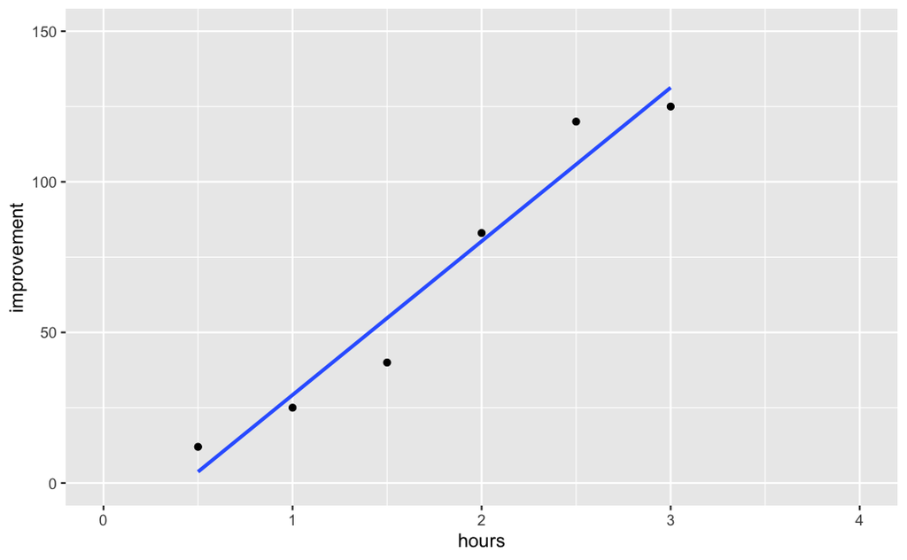

```r
ggplot(data = table_scz, aes(x = hours, y = improvement)) +
  geom_point() +
  geom_smooth(method = "lm", formula = "y ~ x", se= FALSE) +
  xlim(0, 4) +
  ylim(0, 150)
```

- For the table “mpg”, plot the “hwy” as a function of how big is the engine (“displ”) and include a regression line.

## Different groups

In ggplot is easy to plot different groups. Consider the “mpg” table. We first plot “cty” as a function of “hwy”.

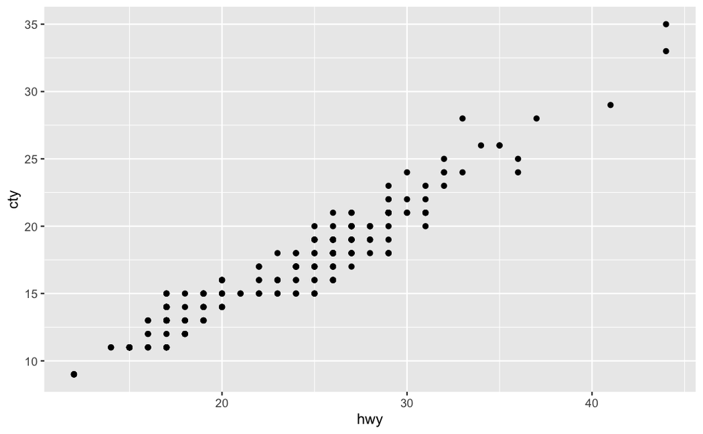

```r
ggplot(data = mpg, aes(x = hwy, y = cty)) +
  geom_point()
```

If we want to include alsoinformation about the transmission (“trans”), we can use, for example, diffferent colors

```r
ggplot(data = mpg, aes(x = hwy, y = cty, color = trans)) +
  geom_point()
```

We can also use different panels

```r
ggplot(data = mpg, aes(x = hwy, y = cty)) +
  facet_wrap(~ trans) +
  geom_point()
```

- For the table “mpg”, plot the “hwy” as a function of how big is the engine (“displ”) using different colors for different manufacturers.
- Now use both color and different panels to present the data for different manufacturers.